M2.883 · Aprendizaje por refuerzo

2023-1 · Máster universitario en Ciencia de datos (*Data science*)

Estudios de Informática, Multimedia y Telecomunicación

# PEC 3: Control de temperatura

En las otras practicas habreis visto que vuestra tarea principal consistia en implementar algoritmos para solucionar entornos de gymnasium. En muchos casos (en especial en el contexto de empresa) uno no tiene los recursos ni el tiempo para poder implementar por si mismo algoritmos de reinforcement learning y se opta por usar librerias.

Al igual que gymnasium (visto en las otras dos practicas) es usado para definir y ejecutar un entorno, existe una libreria llamada [stable-baselines3](https://stable-baselines3.readthedocs.io/en/master/index.html) que implementa algoritmos de reinforcement learning. Esta libreria es compatible con gymnasium.

Que haremos en esta practica? El objetivo de esta practica sera implementar un control de temperaturas usando stable-baselines3 y focalizandonos en algunos de los problemas que hemos pasado por encima en las otras PECS, como por ejemplo:

- Definir la mejor representacion de nuestro espacio de observacion
- Definir la mejor representacion de nuestro espacio de acciones
- Seleccion de hyperparametros
- Modelizacion de la funcion reward

Algunas consideraciones antes de empezar la practica:

- Es normal que en esta practica termineis escribiendo mucho menos codigo. Gran parte de vuestro tiempo durante la practica pasara por ejecutar los algoritmos asi como leer la documentacion de stable baselines 3.
- Esta practica, **a pesar de tratar de control de temperatura, NO REQUIERE DE CONOCIMIENTOS RELACIONADOS CON EL TEMA**. Todas las simulaciones fisicas necesarias para solucionar el problema estan implementadas y testeadas y NO os debeis fijar en estas funciones.

## 1. Introduccion: Problema de control de temperaturas

Para empezar, instalaremos gymnasium y stable_baselines3. Es recomendable hacer uso de google colab para evitar problemas de versiones.

```python
!pip install gymnasium==0.29.1
!pip install stable_baselines3==2.2.1
!pip install opencv-python
```

[output not shown]

[output not shown]

[output not shown]

[output not shown]

[output not shown]

[output not shown]

[output not shown]

[output not shown]

[output not shown]

[output not shown]

[output not shown]

[output not shown]

[output not shown]

[output not shown]

[output not shown]

[output not shown]

[output not shown]

[output not shown]

[output not shown]

[output not shown]

[output not shown]

[output not shown]

[output not shown]

[output not shown]

[output not shown]

[output not shown]

[output not shown]

[output not shown]

[output not shown]

[output not shown]

[output not shown]

Vamos a ponernos en contexto. Imaginad que trabajais en una empresa que se dedica al control de temperaturas para distintas aplicaciones. Se esta disenando un nuevo producto el qual debe controlar la temperatura de una area de 200x200 m2, la qual la representaremos usando una matriz de 200x200 valores indicando la tempratura en cada punto. Para controlar la temperatura de esta area disponemos de una matriz de 3x3 lamparas situadas justo encima de esta area . Estas lamparas son fuentes de luz que irradian desde arriba la superficie a calentar, como se muestra en el siguiente esquema:

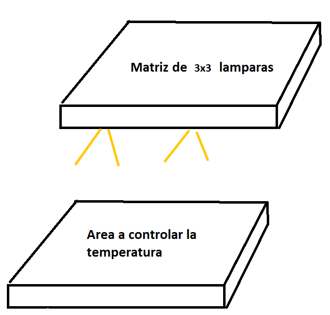

En la siguiente imagen podemos ver marcado con una 'X' la posicion de cada una de las lamparas con respecto a la superficie de 200m2. Se muestra tambien la 'huella de calor' que deja una lampara sobre la superficie. Esta 'huella de calor' no es nada mas que el incremento en temperatura que genera la lampara cuando se enciende. Fijaros que la lampara tiene un perfil difuso i abarca una area bastante amplia debajo suya:

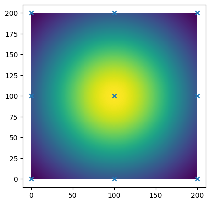

A parte de calentar la superficie con las lamparas, tenemos, como en qualquier superficie caliente, enfriamiento debido a que la superficie esta en contacto con el aire. Esto hace que para mantener la temperatura de la superficie en un cierto valor, haga falta siempre que alguna de las lamparas (o todas) esten minimamente encendidas para compensar estas perdidas.

Que significa que queremos 'controlar la temperatura'? Nuestro producto debe recibir como input una temperatura target y nosotros debemos ir modificando la potencia de las lamparas para que TODOS LOS PUNTOS DE LA SUPERFICIE lleguen, lo antes possible, a una temperatura lo mas cercana possible a la tempetaura target.

La potencia de las lamparas se ha normalizado entre 0 y 1 de tal forma que una lampara que este puesta a una potencia 0 esta apagada i una lampara puesta a potencia 1 esta a su maximo.

Para resumir:

- Tenemos una matriz de 200x200 temperaturas que queremos que sean lo mas parecidas a un target dado
- Disponemos de una matriz de 3x3 lamparas situadas justo encima de la zona a controlar la temperatura las cuales tenemos que definir que potencia deben tener para conseguir la temperatura target en todos los puntos. La potencia es un numero real entre 0 y 1.

**Ejercicio 1.1**: Primer analisi del problema (0.5 puntos). Para el problema descrito anteriormente responde a las siguientes preguntas:

- Cuales son las possibles acciones que podemos hacer? Se puede tratar este problema como un espacio discreto o continuo de acciones? Como serian las acciones en el caso continuo? Y en el caso discreto?
- Dado un target, como podriamos describir el estado del entorno? Propon dos descripciones y comenta que ventajas e inconvenientes tiene cada una.

**Comentario:** 1. Nos enfrentamos a un entorno donde se permiten realizar tanto acciones discretas como continuas. En el caso de las acciones continuas se podria definir como un intervalo entre 0 y 1 permitiendo elegir numeros con 2 o decimales. Esto permite que el entorno se pueda controlar de una forma mas precisa. En el caso de las acciones discretas, se deberia de definir cuantas acciones queremos para nuestro entorno, por ejemplo subir temperatura, bajar temperatura o mantener temperatura. 2. Podemos encontrarnos con varias descripciones del entorno. 2.1. representar el estado del entorno como la matriz de las temperaturas en cada metros cuadrado de la superficie y la matriz de las potencias de sus bombillas. **Ventajas**: se proporciona una informacion detallada del estado de lconjunto de elementos del entonro y como las acciones repercuten en el mismo. **Desventajas**:la representacion detallada de este entorno puede llevar a un costo computacional elevado al procesar y analizar la información. **2.2.** Realizar las temperaturas promedio de la superficie, la desciacion estandar de las temp de la superficie y la potencia promedio de las lamparas. **Ventajas**: proporciona vision general y facil de interpretar del estado de entorno y puede ser mas eficiente computacionalmente que el anterior. **Desventajas**: puede no representar detalles importantes sobre como varia la temperatura en diferentes areas y como afectan las potencias de las lamparas en sus determinadas ubicaciones.

Antes de empezar.....

Daros cuenta que el problema de control de temperaturas en este caso es dificil debido al perfil gausiano de las lamparas y a que cada lampara incide no solo en el area immediata justo debajo suya sino que su potencia llega tambien a sus lamparas vecinas. Esto genera que, si ponemos todas las lamparas a maxima potencia (potencia = 1), el perfil de potencia que incide sobre la superficie que queremos controlar sea menor en las esquinas. Esto se puede ver en la siguiente imagen donde se muestra la potencia recibida en cada punto si todas las lamparas estan encendidas

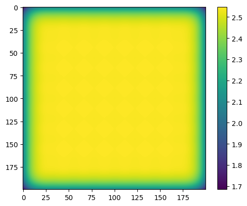

Vamos a ver ahora las funciones para generar las matrices de incidencia de cada una de las lamparas

```python
import numpy as np
import matplotlib.pylab as plt

#Funciones para genenerar la matriz de lamparas con perfil Gaussiano. Lo podeis ignorar
def gauss_centered(center,sig,N):
  x,y = np.meshgrid(np.arange(N),np.arange(N))
  M = np.exp(-1*((x-center[0])**2+(y-center[1])**2)/sig**2)
  return M


def generate_centroids(K,N):
  centroids = np.linspace(0,N,K)
  centroids = [[value,value_2] for value in centroids for value_2 in centroids]
  return centroids


def generate_lamp_array(N,K,sig,show = False):
  '''
  Esta funcion devuelve una matriz de K^2xNxN
  con la incidendia de cada lampara en cada uno de los puntos.
  '''
  centroids = generate_centroids(K,N)
  M = [gauss_centered(center,sig,N) for center in centroids]
  if show:
    plt.scatter(np.array(centroids)[:,1],np.array(centroids)[:,0],marker = 'x')
    plt.imshow(np.array(M)[4])
    plt.xlim(-10,10+N)
    plt.ylim(-10,10+N)
  return np.array(M)
```

```
(9, 200, 200)
```

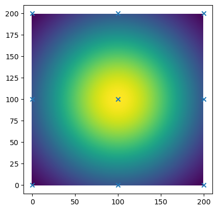

```python
N = 200 #Tamanyo del area a controlar
K = 3 #Numero de lamparas por eje
N_LAMPS = K**2 # EL numero de lamparas sera de KxK
SIG  = 100
 #sigma de la distribucion gausiana. Define como de difuso es el perfil de la lampara

LAMP_ARRAY = generate_lamp_array(N,K,SIG,show = True) #Te devuelve una matriz de 9x200x200 elementos donde el elemento [i,:,:] es la incidencia de la lampara i sobre el area
print (LAMP_ARRAY.shape)
```

La funcion importante con respecto a las lamparas es la que viene en la siguiente celda de codigo. En esta funcion, dado un array con potencias, nos devuelve en forma de matriz 200x200 la potencia total recibida por cada uno de los puntos

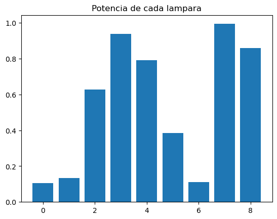

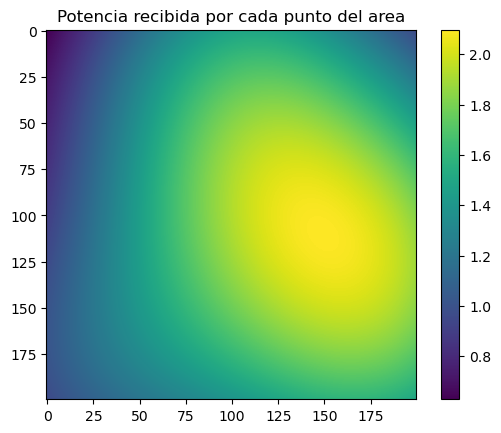

```python
def get_applied_P(lamp_array,lamp_power):
  #Dado un array de potencias, devuelve la potencia que incide sobre el area a controlar
  return (lamp_array.T*lamp_power).T.sum(axis = 0)

lamp_power = np.random.rand(N_LAMPS)
P = get_applied_P(LAMP_ARRAY, lamp_power)

plt.bar(np.arange(N_LAMPS),lamp_power)
plt.title('Potencia de cada lampara')
plt.show()

plt.imshow(P)
plt.colorbar()
plt.title('Potencia recibida por cada punto del area')
plt.show()
```

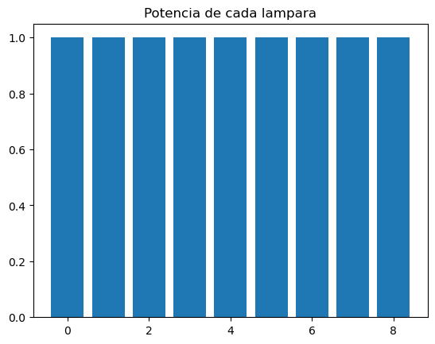

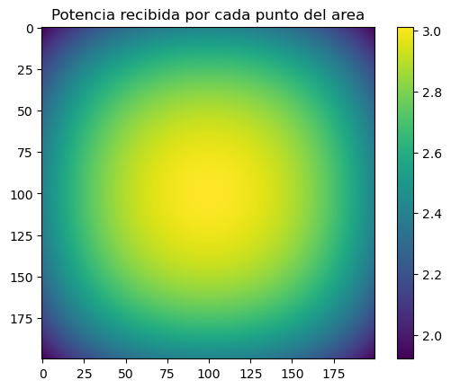

```python
#Podemos ver qual es el perfil que resulta si ponemos todas las lamparas a 1
lamp_power = np.ones(N_LAMPS)
P = get_applied_P(LAMP_ARRAY, lamp_power)

plt.bar(np.arange(N_LAMPS),lamp_power)
plt.title('Potencia de cada lampara')
plt.show()
plt.imshow(P)
plt.colorbar()
plt.title('Potencia recibida por cada punto del area')
plt.show()
```

En la siguiente celda se declara la funcion usada para simular el calentamiento del area a controlar debido a las lamparas y el enfriamiento debido al aire que circula por encima del area.

Se muestra un ejemplo donde, data una temperatura de 100 grados y poniendo todas las lamparas a 0.3 durante 3 mil iteraciones, se llega a una temperatura de 160 grados

```
Ultima temperatura 159.30165100097656
```

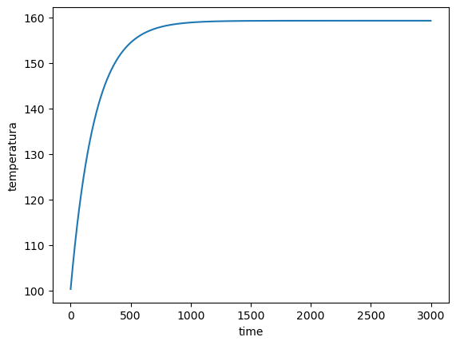

```python
import cv2
import time

#CONSTANTES FISICAS PARA SIMULAR EL PROCESO DE CALENTAMIENTO/ENFRIAMIENTO

CONV_MAP = 1 #mapa de conveccion.
CONV_COEF = 0.005 #Coeficiente de conveccion. Como mas grande es, mas rapido se enfria la superficie
CP = 0.1 # Coeficiente que determina como de sensible es la temperatura a la potencia. A mas grande, mas sensible eres a la potencia.


def simulate_single_step(applied_P,conv_coef,T):
  T+=applied_P-conv_coef*T #Aplicamos la potencia de las lamparas y conveccion
  T = cv2.GaussianBlur(np.float32(T),(9,9),0) #aplicamos conduccion. Ignorad este paso.
  return T

T = np.zeros((N,N))+100 #Iniciamos la matriz a temperatura 100
lamp_power = np.ones(N_LAMPS)*0.3 #Ponemos las lamparas a 0.3
P = get_applied_P(LAMP_ARRAY,lamp_power) #Potencia recibida en cada punto con las lamparas a 0.3

avg_T = [] #Guardamos la temperatura promedio en cada paso

STEPS = 3000
for i in range(STEPS):
  T = simulate_single_step(P,CONV_COEF,T)
  avg_T.append(np.mean(T))
print (f'Ultima temperatura {avg_T[-1]}')

plt.plot(avg_T)
plt.xlabel('time')
plt.ylabel('temperatura')
```

**Ejercicio 1.2 (0.25 puntos):** Para familiarizarte con el entorno, busca a traves de prueba y error que potencia debemos poner en las lamparas para conseguir que la temperatura estabilize a 140 grados (mas o menos) partiendo de una temperatura inicial de 100 grados. Usad 3000 iteraciones como antes. Mostrad una grafica con la evolucion de la temperatura asi como el perfil de temperaturas que queda al final, por ejemplo, haciendo un imshow de la matriz de temperatura final. Pista: Para simplificar, poned todas las lamparas a la misma potencia i usad el caso anterior, donde si poniamos las lamparas a 0.3 se llegaba a 160 grados. Haciendo esto deberiais tener, mas o menos, el siguiente perfil de temperaturas/evolucion de temperatura:

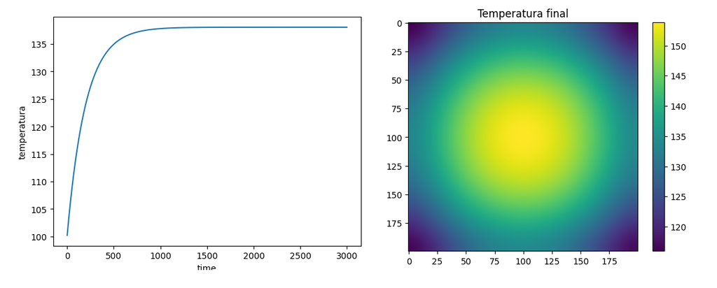

```python
lamp_power = np.ones(N_LAMPS)*0.27
```

```
Ultima temperatura 143.37144470214844
```

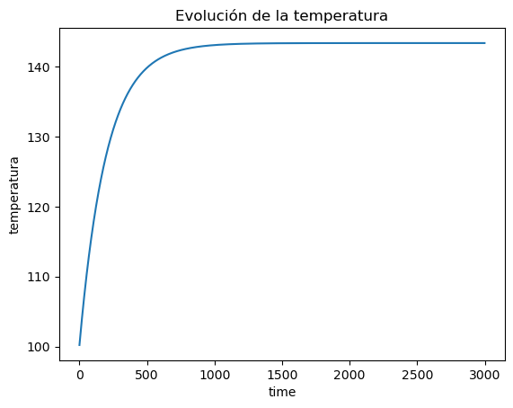

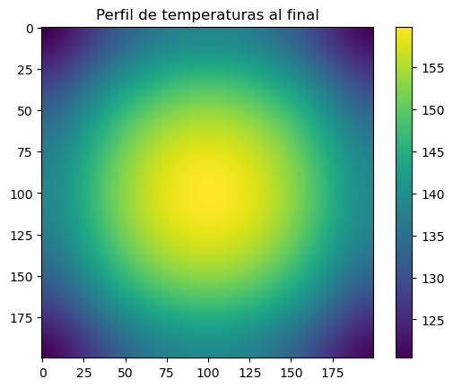

```python
#TODO: EJERCICIO 1.2
import cv2
import time

#CONSTANTES FISICAS PARA SIMULAR EL PROCESO DE CALENTAMIENTO/ENFRIAMIENTO

CONV_MAP = 1 #mapa de conveccion.
CONV_COEF = 0.005 #Coeficiente de conveccion. Como mas grande es, mas rapido se enfria la superficie
CP = 0.1 # Coeficiente que determina como de sensible es la temperatura a la potencia. A mas grande, mas sensible eres a la potencia.


def simulate_single_step(applied_P,conv_coef,T):
  T+=applied_P-conv_coef*T #Aplicamos la potencia de las lamparas y conveccion
  T = cv2.GaussianBlur(np.float32(T),(9,9),0) #aplicamos conduccion. Ignorad este paso.
  return T

T = np.zeros((N,N))+100 #Iniciamos la matriz a temperatura 100
P = get_applied_P(LAMP_ARRAY,lamp_power) #Potencia recibida en cada punto con las lamparas a 0.3

avg_T = [] #Guardamos la temperatura promedio en cada paso

STEPS = 3000
for i in range(STEPS):
  T = simulate_single_step(P,CONV_COEF,T)
  avg_T.append(np.mean(T))
print (f'Ultima temperatura {avg_T[-1]}')

plt.figure(1)
plt.plot(avg_T)
plt.xlabel('time')
plt.ylabel('temperatura')
plt.title('Evolución de la temperatura')

# Muestra el perfil de temperaturas al final
plt.figure(2)
plt.imshow(T)
plt.colorbar()
plt.title('Perfil de temperaturas al final')

plt.show()
```

## 2.Definicion del entorno

Antes de empezar con el propio entorno, vamos a generar los espacios de acciones posibles a realizar. Para poder probar los distintos algoritmos imlpementaremos:

- Espacios discretos:
  - Un espacio de acciones donde las acciones sean discretas i donde todas las potencias de las 9 lamparas se modifiquen a la vez
  - Un espacio de acciones donde las acciones sean discretas i donde cada lampara se modifique cada vez

  Para estos espacios, la accion 0 sera bajar la potencia , la accion 1 sera mantener la potencia i la accion 2 sera subir la potencia.
- Un espacio de acciones continuo, donde se generen 9 valores entre -1 i 1 que definan que modificacion en la potencia queremos hacer.

```python
import gymnasium as gym

class LampArrayPowerModifications_global(gym.spaces.Discrete):
  def __init__(self):
    super().__init__(3)
    self.action_to_string_map = {0:'decrease',1:'nothing',2:'increase'}
    self.name = 'global_discrete'

  def get_action_name(self,action):
    return self.action_to_string_map[action]

  def sample(self):
    action = super().sample()
    return action

actions = LampArrayPowerModifications_global()
actions.sample()
```

```
1
```

```python
class LampArrayPowerModifications_discrete(gym.spaces.Discrete):
  #Las acciones del 1 al 18 corresponden a subir/bajar las 9 lamparas. De la 19-21 corresponde a bajar, mantener o subir la potencia de todas a la vez (como antes)
  def __init__(self,n_lamps):
    super().__init__(2*n_lamps+3)
    decrease_increase_map = {0:'decrease',
                             1:'increase'}
    decrease_increase_map_value = {0:0,
                             1:2}
    self.action_to_string_map = {i:f'lamp_{i//2+1}_{decrease_increase_map[i%2]}' for i in range(2*n_lamps)}
    self.action_to_tuple_map = {i:(i//2, decrease_increase_map_value[i%2]) for i in range(2*n_lamps)}

    self.n_lamps = n_lamps
    self.name = 'individual_discrete'

  def get_action_name(self,action):
    if action>=self.n_lamps*2:
      action -=self.n_lamps*2
      if action==0:
        string = 'decrease'
      elif action==1:
        string  = 'nothing'
      else:
        string = 'increase'

      return 'all_'+string
    else:
      return self.action_to_string_map[action]

  def get_action_array(self,action):
    #Dada una accion, de devuelve el array con la subida de potencia
    if action>=self.n_lamps*2:
      # SI la accion es una de las 3 globales (acciones 19 20 i 21), devuelve los numeros 0 1 o 2
      return action-self.n_lamps*2
    else:
      #Si no construye un vector de 1's (recordad que 1 = dejar las potencias iguales) donde la lampara seleccionada tomara valores 0 o 2 en funcion de si baja o sube
      tuple_ = self.action_to_tuple_map[action]
      lamp_power = np.ones(self.n_lamps)
      lamp_power[tuple_[0]] = tuple_[1]
      return lamp_power

  def sample(self):
    action = super().sample()
    return action

actions = LampArrayPowerModifications_discrete(n_lamps = N_LAMPS)
for _ in range(10):
  sample = np.random.randint(N_LAMPS*2+3)
  print (actions.get_action_array(sample))
  print (actions.get_action_name(sample))
  print('\n\n')
```

```
[1. 0. 1. 1. 1. 1. 1. 1. 1.]
```

```
lamp_2_decrease
```

```
[1. 1. 1. 1. 1. 1. 2. 1. 1.]
```

```
lamp_7_increase
```

```
[1. 1. 1. 0. 1. 1. 1. 1. 1.]
```

```
lamp_4_decrease
```

```
[1. 1. 1. 1. 0. 1. 1. 1. 1.]
```

```
lamp_5_decrease
```

```
[1. 1. 2. 1. 1. 1. 1. 1. 1.]
```

```
lamp_3_increase
```

```
[1. 1. 1. 1. 1. 1. 1. 1. 0.]
```

```
lamp_9_decrease
```

```
[1. 0. 1. 1. 1. 1. 1. 1. 1.]
```

```
lamp_2_decrease
```

```
[1. 1. 1. 1. 1. 1. 1. 1. 2.]
```

```
lamp_9_increase
```

```
[1. 1. 1. 1. 1. 1. 1. 1. 2.]
```

```
lamp_9_increase
```

Antes de definir el entorno generaremos una funcion para calcular la recompensa que recibe el actor.

Que esperamos de esta funcion?

- Recibe como parametros de entrada la matriz de temperatura actual i un valor con la temperatura target
- La recompensa debe ser inversamente proporcional a la diferencia entre la temperatura actual i la temperatura target

```python
class LampArrayPowerModifications_continious(gym.spaces.Box):
  #Genera un vector con las modificaciones de las potencias de las lamparas
  def __init__(self,n_lamps):
    super().__init__(low = np.array([-1]*n_lamps),high = np.array([1]*n_lamps))
    self.n_lamps = n_lamps
    self.name = 'individual_continious'


  def sample(self):
    action = super().sample()
    return action

actions = LampArrayPowerModifications_continious(n_lamps = N_LAMPS)
actions.sample()
```

```
array([-0.18284911, -0.50373065,  0.02805275, -0.23591809, -0.52507615,
       -0.18148308, -0.25863716,  0.4015449 ,  0.31762585], dtype=float32)
```

**Comentario:**

Ejercicio 2.1 (0.75 puntos): Propon 3 versiones de la funcion de recompensa dentro de la funcion `calculate_reward`. Explica las diferencias entre ellas i qual crees, a priori, que puede funcionar mejor. Genera tambien una funcion que devuelva los rangos de cada funcion de recompensa (minimo,maximo) e implementalo dentro de la funcio `get_reward_range`. Esta ultima funcion nos servira para conocer el rango de la reward dentro del entorno. Nota: de las 3 versiones se proporciona una ya implementada a modo de ejemplo

```python
def calculate_reward(T,target_temp,method = 'method_1'):
  #debe devolver un unico valor de recompensa
  if method=='negative_error':
    #un ejemplo de funcion de error
    return np.mean(1+ -0.1*(T-target_temp)**2)

  elif method=='method_1':
    return (T-target_temp)

  elif method=='method_2':
    if T/target_temp >= 0 and T/target_temp < 0.25:
      reward = -2

    elif T/target_temp >= 0.25 and T/target_temp < 0.50:
      reward = -1

    elif T/target_temp >= 0.50 and T/target_temp < 0.75:
      reward = 1

    elif T/target_temp >= 0.75 and T/target_temp < 1:
      reward = 2

    elif T/target_temp == 1:
      reward = 10

    else:
      reward = -10

    return reward

  else:
    return -np.mean(np.log(1 + np.abs(T - target_temp)))
```

```python
def get_reward_range(method = 'method_1'):
  #Debe devolver una tupla (min,max)
  if method=='negative_error' :
    #Por ejemplo, si el reward puede ir de -inf a inf devolvemos (-1*np.inf,np.inf)
    return (-1*np.inf,1)
  elif method=='method_1':
    return (np.min(target_temp), np.max(target_temp))
  elif method=='method_2':
    return (-10, 10)
  else:
    return (-1 * np.inf, 0)
```

Ahora definiremos las distintas observaciones possibles. Existen varias opciones distintas para el espacio de observaciones:

- Temperature mode ('average'/'lamp' o 'image') : Si es 'average', devuelve la temperatura promedio. Si es 'image' devuelve la temperatura en cada punto (array de 40 mil valores). Si es 'lamp' subdivide el espacio en una matriz de 3x3 y devuelve 9 temperaturas.
- Normalize temperature (True/False): Si es True, normaliza las temperaturas dividiendolas por el target. Si es false, devuelve las temperaturas sin modificar y añade el target al array de temperturas.
- Return power (True/False): Si se devuelve o no la potencia de las lamparas como observacion
- Power mode ('average'/'lamp'): Si es 'average' se devuelve la potencia promedia. Si es 'lamp', se devuelven las 9 potenias.
- Buffer size (int): El tamanyo del buffer de imagenes de temperatura que queremos dar como observacion. Debe ser siempre >2.

Fijaros que todas estas opciones son al final hiperparametros con los que podreis jugar cuando entreneis vuestra DQN mas adelante

Ejercicio 2.2 (0.25 puntos): Completa los comentarios de la classe `TemperatureEnvObservation` explicando que hace cadascuna de las partes. Hay que completar los comentarios con `#TODO: Comentar`

```python
class TemperatureEnvObservation():

  def __init__(self,
               temperature_mode = 'average',
               normalize_temperature = False,
               return_power = True,
               power_mode= 'average',
               buffer_size = 3):

    assert(buffer_size>=2) #TODO: Comentar =   EL BUFFER TIENE QUE TENER UN TAMAÑO DE AL MENOS 2
    self.temperature_mode = temperature_mode
    self.buffer_size = buffer_size
    self.normalize_temperature = normalize_temperature

    self.power_mode = power_mode
    self.return_power = return_power

  def get_observation(self,temperature_image_buffer,lamp_power,target):

    #################################
    #Observaciones de la temperatura#
    #################################

    if self.temperature_mode == 'average':#TODO: Comentar = SI LA TEMPERATURA MODE ES AVERAGE SE CALCULA LA TEMPERATURA PROMEDIO
      temperature_buffer = np.mean(temperature_image_buffer,axis = -1).mean(axis=-1)

    elif self.temperature_mode =='lamp': #TODO: Comentar = SI ES LAMP SUBDIDIVIDE EL ESPACIO EN UNA MATRIZ 3X3 Y DEVUELVE LAS 9 POTENCIAS
      temperature_buffer = np.array([cv2.resize(temp,dsize= (K,K)).reshape(-1) for temp in temperature_image_buffer]).reshape(-1)

    elif self.temperature_mode=='image': #TODO: SI ES IMAGE DEVUELVE LA TEMPERATURA EN CADA PUNTO EN TOTAL 40.000 VALORES (200X200)
      temperature_buffer = np.copy(temperature_image_buffer)

    #TODO: Comentar, que hace el normalize temperature? = SI ES TRUE, NORMALIZA LAS TEMPERATURAS DIVIDIENDOLAS POR EL TARGET Y CONVIERTE EN LISTA Y SI ES FALSE, DEVUELVE LAS TEMPERATURAS SIN MODIFICAR Y AÑADE EL TARGET AL ARRAY DE TEMPERATURAS
    if self.normalize_temperature:
      temperature_buffer = (temperature_buffer/target).tolist()
    else:
      temperature_buffer = temperature_buffer.tolist()+[np.mean(target)]

    ##############################
    #observaciones de la potencia#
    ##############################

    power = []
    if self.return_power:
      if self.power_mode=='average': #TODO: Comentar = SI ES AVERAGE SE DEVUELVE LA POPOTENCIA PROMEDIA
        power =  [np.mean(lamp_power)]
      elif self.power_mode =='lamp': #TODO: Comentar = SI ES LAMP SE DEVUELVEN LAS 9 POTENCIAS DE LAS LAMPARAS
        power =  lamp_power.tolist()

    #TODO: Comentar SE DEVULVE UN ARRAY DE LA COMBINACION DEL BUFFER DE TEMPERATURA Y EL DE LAS POTENCIAS EXTRAIDO ANTERIOR MENTE
    return np.array(temperature_buffer+power)

  def get_observation_space(self):
    #Observaciones de la temperatura
    lows = []
    highs = []
    if self.temperature_mode == 'average':
      lows += [-np.inf]*self.buffer_size
      highs += [np.inf]*self.buffer_size

    elif self.temperature_mode =='lamp':
      lows += [-np.inf]*self.buffer_size*K**2
      highs += [np.inf]*self.buffer_size*K**2

    elif self.temperature_mode=='image':
      raise NotImplementedError('Image method not implemented')
      temperature_buffer = np.copy(temperature_image_buffer)

    if not self.normalize_temperature:
      lows += [-np.inf]
      highs += [np.inf]

    #observaciones de la potencia
    power = []
    if self.return_power:
      if self.power_mode=='average':
        lows += [0]
        highs += [1]
      elif self.power_mode =='lamp':
        lows += [0]*K**2
        highs += [1]*K**2

    #devolver todo
    return gym.spaces.Box(low = np.array(lows), high = np.array(highs))
```

Ahora vamos a definir el entorno. Esto ya lo habeis practicado en otras PECS, asi que en este caso el entorno se da totalmente definido.

```python
import numpy as np
class TemperatureEnv(gym.Env):
  def __init__(self,
               N, #Tamanyo del area a controlar
               K, #Numero de lamparas por eje
               sigma, #desviacion estandar de las lamparas
               To, #Temperatura inicial
               conv_coef, #coeficiente de conveccion
               actions, #espacio de acciones
               observation:TemperatureEnvObservation(), #Objeto con las observaciones
               reward_method:str, #tipo de reward escogido entre las opciones que habeis programado.,
               lamp_increase = 0.05, #incremento de la lampara en caso del espacio discreto
               target_range = (100,160), #rango en el que puede variar el target.
               max_steps = 600, #Numero maximo de steps antes de  trucar cada episodio
               iterations_per_action = 5, #Cada vez que se realiza una accion, quantas veces se deja evolucionar el entorno antes de dejar tomar la siguiente accion.
               is_eval = False #Flag para saber si el entorno se usa para evaluar o no. Si es True, el entorno usa una temperatura constante cada vez que se hace el reset (no usa el target range)
               ):

    self.N = N
    self.n_lamps_per_direction = K
    self.n_lamps = K**2

    self.To = To #temperatura inicial con la que empezamos
    self.conv_coef  = conv_coef #coeficiente de conveccion
    self.sigma = sigma #ancho del efecto de la lampara

    self.lamp_increase = lamp_increase #incremento de la lampara en caso del espacio discreto
    self.max_steps = max_steps #maximo numero de passos para conseguir la temperatura target
    self.target_range = target_range #Rango de temperaturas del target

    self.lamp_array = self.load_lamps_map() #cargamos el array de lamparas

    self.action_space = actions #acciones a tomar

    self.observation = TemperatureEnvObservation() #Numero de observaciones a hacer.

    self.iterations_per_action = iterations_per_action #numero de iteraciones por accion.


    #TODO: ajustar las acciones segun si el nombre de action_space es individual discrete o no
    if self.action_space.name =='individual_discrete':
      self.modify_action = lambda x: self.action_space.get_action_array(x)
    else:
      self.modify_action = lambda x: x

    #TODO: comprobar si el espacio de acciones es continuo
    self.is_continious = False
    if 'continious' in self.action_space.name:
      self.is_continious = True

    self.reward_range = get_reward_range(reward_method) #rango del reward
    self.observation_space = self.observation.get_observation_space() #espacio de observaciones

    self.reward_method = reward_method
    self.is_eval = is_eval
    self.reset()


  def step(self,action):
    #TODO: cambiar la potencia de la lampara segun las acciones si son continuas o discretas
    if self.is_continious:
      self.lamp_power+=action
    else:
      action = self.modify_action(action)
      self.lamp_power+=self.lamp_increase*(action-1)

    #TODO: se comprueba si la potencia de de la lampara se encuentra dentro del rango permitido [0,1]
    self.lamp_power = np.clip(self.lamp_power,0,1)

    #Simulamos que dejamos las lamparas a la nueva potencia durante self.iterations_per_actions
    for _ in range (self.iterations_per_action):
      self.simulate() #evoluciona la temperatura


    #truncar si se llega al limite de steps
    if self.current_time >= self.max_steps:
      truncated = True
    else:
      truncated = False

    #Calculamos el reward
    reward = self.get_reward()

    #TODO: agregar temperatura actua al buffer y se eimina La mas antigua que se encuentra
    self.temperature_buffer.append(self.temperature)
    del self.temperature_buffer[0]

    #Calculamos la observacion
    obs = self.get_observation()

    #TODO: se acrea el diccionario info con la informacion de la temperatura media, la temperatura media objetivo,
    #      la media de la potencia de la lampara, la recompensa, el tiempo de ejecucion y el numero de  pasos que se han realizado
    info = {'avg_temperature':self.temperature.mean(),
            'target_temperature':self.target.mean(),
            'avg_power':self.lamp_power.mean(),
            'reward':reward,
            'time':self.current_time,
            'max_time':self.max_steps}

    return obs,reward,False,truncated,info

  def get_observation(self):
    return self.observation.get_observation(self.temperature_buffer,self.lamp_power,self.target)

  def get_reward(self):
    return calculate_reward(self.temperature,self.target.mean(),self.reward_method)


  def simulate(self):
    #Calcular la potencia aplicada i simular la evolucion de la temperatura
    applied_P = get_applied_P(self.lamp_array,self.lamp_power)
    self.temperature = simulate_single_step(applied_P,
                         self.conv_coef,
                         self.temperature)
    self.temperature[self.temperature<0] = 0

    #Sumar 1 al timepo passado
    self.current_time += 1

  def init_power_array(self):
    #iniciamos las lamparas a potencia = 0
    return np.zeros(self.n_lamps)

  def load_lamps_map(self):
    #Generar el mapa de lamparas
    return generate_lamp_array(self.N,self.n_lamps_per_direction,self.sigma)

  def init_temperature(self):
    #iniciamos las temperatura a To
    return np.zeros((N,N))+self.To

  def generate_random_target(self):
    #Generamos la matriz de temperatura target de forma random
    if self.is_eval:
      current_target_temp = np.mean(self.target_range) #TODO: temperatura objetivo actual es la media del rango objetivo
    else:
      #Si el entorno no es de evaluacion, selecciona la temperatura target de forma random.
      current_target_temp = np.random.choice(np.arange(self.target_range[0],self.target_range[1],0.5))

    return np.ones(shape = (self.N,self.N))*current_target_temp


  def reset(self,seed = None):
    self.lamp_power = self.init_power_array() #Resetear potencia de las lamparas
    self.temperature = self.init_temperature() #Resetear temperatura
    self.current_time = 0 #Resetear tiempo
    self.target = self.generate_random_target() #Resetear target
    self.temperature_buffer = [self.temperature]*self.observation.buffer_size #TODO: crear lista con la temperatura repetida las veces que se encuentre el valor observation.buffer_size
    return self.get_observation(),{}
```

Vamos a testear ahora que el entorno funciona. Pongamos una temperatura inicial de 80 grados, un lamp_increase de 0.05 y usemos las modificaciones globales de la potencia. Para la funcion de reward, usaremos la que se os ha dado por defecto.

Vamos a guardar la informacion que nos devuelve el entorno en una lista.

```python
To = 80 #Temperatura inicial

actions = LampArrayPowerModifications_global()
observation_space = TemperatureEnvObservation()
env = TemperatureEnv(N,
               K,
               SIG,
               To,
               CONV_COEF,
               actions,
               observation_space,
               reward_method = 'negative_error')


obs, _ = env.reset()
info_history = []
for i in range(500):
  action = env.action_space.sample()
  obs, reward, terminated,truncated, info = env.step(int(action))
  info_history.append(info) #Guardamos la informacion del entorno en una lista

  if truncated or terminated:
    break
```

**Ejercicio 2.4 (0.25) puntos:** Imprimid la informacion devuelta por el entorno. Describid brevemente lo que se devuelve.

```python
print("Observación:", obs)
print("Recompensa:", reward)
print("Terminado:", terminated)
print("Truncado:", truncated)
print("Información adicional:", info)
```

```
Observación: [5.61057129e+01 5.48501854e+01 5.42886086e+01 1.06000000e+02
 5.00000000e-02]
Recompensa: -267.47754
Terminado: False
Truncado: True
Información adicional: {'avg_temperature': 54.288612, 'target_temperature': 106.0, 'avg_power': 0.05, 'reward': -267.47754, 'time': 600, 'max_time': 600}
```

```python
print(info_history)
```

```
[{'avg_temperature': 78.019905, 'target_temperature': 106.0, 'avg_power': 0.0, 'reward': -77.28856, 'time': 5, 'max_time': 600}, {'avg_temperature': 76.74561, 'target_temperature': 106.0, 'avg_power': 0.05, 'reward': -84.58225, 'time': 10, 'max_time': 600}, {'avg_temperature': 76.1597, 'target_tempe…
```

Lo que devuelve la info story es una lista que conteien los diccionarios de la temperatura media del entorno que cada paso que se ha dado, la temperatura promedio objetiva, la potencia media de las lamparas en cada paso, la recompensa en cada paso, el paso actual que se encuentra y el maximo de pasos que se permiten hasta truncar el episodio

**Ejercicio 2.5 (0.5) puntos:** Completa la funcion `analyze_run` donde, dada la lista de informacion `info_hist` se muestre: * La evolucion de la temperatura promedio , con el target como una linea de referencia * La evolucion de la potencia media en el tiempo * La evolucion de las rewards en el tiempo. Ejecutala para el caso anterior

```python
def analyze_run(info_hist):
    # Extraer información relevante de info_hist
    temperatures = [info['avg_temperature'] for info in info_hist]
    target_temperature = [info['target_temperature'] for info in info_hist]

    powers = [info['avg_power'] for info in info_hist]

    rewards = [info['reward'] for info in info_hist]

    # Crear gráficos
    fig, axs = plt.subplots(3, 1, figsize=(10, 12))

    # Gráfico de evolución de la temperatura promedio con el objetivo como línea de referencia
    axs[0].plot(temperatures, label='Average Temperature')
    axs[0].plot(target_temperature, label='Target Temperature', linestyle='--', color='red')
    axs[0].set_xlabel('Tiempo')
    axs[0].set_ylabel('Temperatura Promedio')
    axs[0].set_title('Evolución de la Temperatura Promedio')
    axs[0].legend()

    # Gráfico de evolución de la potencia media en el tiempo
    axs[1].plot(powers, label='Average Power')
    axs[1].set_xlabel('Tiempo')
    axs[1].set_ylabel('Potencia Media')
    axs[1].set_title('Evolución de la Potencia Media')

    # Gráfico de evolución de las recompensas en el tiempo
    axs[2].plot(rewards, label='Reward')
    axs[2].set_xlabel('Tiempo')
    axs[2].set_ylabel('Recompensa')
    axs[2].set_title('Evolución de las Recompensas')

    plt.tight_layout()
    plt.show()
```

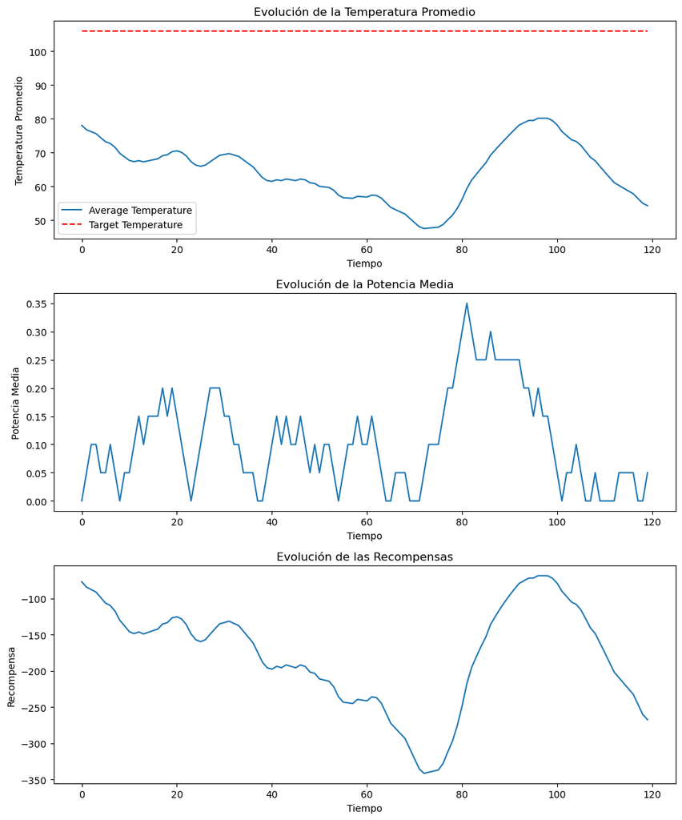

```python
#Ahora la ejecutamos para el caso anterior
analyze_run(info_history)
```

## 3. Entrenamiento del agente

Ahora vamos a entrenar una DQN y vamos a buscar los mejores hiperparametros. Para ello como ya se ha dicho se hara uso de la libreria stable-baselines3.

```python
from stable_baselines3 import DQN
from stable_baselines3.common.evaluation import evaluate_policy
from stable_baselines3.common.callbacks import EvalCallback
```

Antes de empezar con el ejercicio, leed la documentacion de [DQN](https://stable-baselines3.readthedocs.io/en/master/modules/dqn.html) y de [EvalCallback](https://stable-baselines3.readthedocs.io/en/master/guide/callbacks.html) en stable-baselines3.

Ejercicio 3.1 (2.5 puntos) : Este ejercicio se divide en 2 partes que hay que hacer de forma simultanea. 3.1.1 (2 puntos): Crea un modelo DQN con una 'MlpPolicy' para solucionar el problema de control de temperatura usando un como espacio de acciones las acciones globales (LampArrayPowerModifications_global). Hay que encontrar los mejores hyperparametros entre: * learning_starts * target_update_interval * learning_rate * exploration_factor Hay muchos hyperparametros a buscar. Algunos de ellos (buffer size, tipologia de observacion, funcion de reward...) se pueden escoger sin necesidad de entrenar el modelo. Otros como el learning_starts, target_update_interval o learning_rate requieren de buscar distintos valores e ir viendo como mejora la funcion de error. IMPORTANTE: No es necesario hacer +40 mil iteraciones de entrenamiento. 3.1.2 (0.5 puntos): Un problema que os encontrareis durante la ejecucion es que el entrenamiento es inestable. Una forma de lidiar con esto es usar el EvalCallback. Esto nos permit evaluar el modelo de forma periodica y, en caso de que sea el mejor modelo hasta el momento, guarda el modelo entrenado en un zip. Esto nos permite, a posteriori, cargar el mejor modelo visto durante el entrenamiento y usarlo. Usad este callback para ir guardando el modelo durante el entrenamiento

```python
actions = LampArrayPowerModifications_global()
observation_space = TemperatureEnvObservation()
reward_method = 'negative_error'
env = TemperatureEnv(N,
                     K,
                     SIG,
                     To,
                     CONV_COEF,
                     actions,
                     observation_space,
                     reward_method=reward_method)

# Crea un entorno de evaluación para el callback
env_eval = TemperatureEnv(N,
                          K,
                          SIG,
                          To,
                          CONV_COEF,
                          actions,
                          observation_space,
                          reward_method=reward_method,
                          is_eval=True)

# Define el modelo DQN y los hiperparámetros
model = DQN("MlpPolicy",
            env,
            learning_starts=1000,  # Comienza a aprender después de 1000 pasos de tiempo
            target_update_interval=250,  # Actualiza la red objetivo cada 500 pasos de tiempo
            learning_rate=0.01,  # Tasa de aprendizaje para el optimizador
            buffer_size=500,  # Tamaño del búfer de reproducción
            exploration_fraction=0.2,  # Fracción de pasos de tiempo totales durante los cuales se utiliza la política de exploración
            tensorboard_log='./logs')

# Define el callback de evaluación
callback = EvalCallback(eval_env=env_eval,
                        eval_freq=10000,  # Evalúa el modelo cada 1000 pasos de tiempo
                        best_model_save_path='./')

# Evaluación inicial
initial_eval = evaluate_policy(model, env_eval, n_eval_episodes=5, deterministic=True)

# Entrena el modelo
model.learn(total_timesteps=40000,  # Total de pasos de tiempo de entrenamiento
            callback=callback,
            progress_bar=True)

# Evaluación final
final_eval = evaluate_policy(model, env_eval, n_eval_episodes=5, deterministic=True)
```

```
Output()
```

```
Eval num_timesteps=10000, episode_reward=-4034.26 +/- 0.00
```

```
Episode length: 120.00 +/- 0.00
```

```
New best mean reward!
```

```
Eval num_timesteps=20000, episode_reward=-3250.56 +/- 0.00
```

```
Episode length: 120.00 +/- 0.00
```

```
New best mean reward!
```

```
Eval num_timesteps=30000, episode_reward=-3245.45 +/- 0.00
```

```
Episode length: 120.00 +/- 0.00
```

```
New best mean reward!
```

```
Eval num_timesteps=40000, episode_reward=-3387.01 +/- 0.00
```

```
Episode length: 120.00 +/- 0.00
```

```python
print(f'Initial evaltuation {initial_eval}')
print(f'Final evaltuation {final_eval}')
```

```
Initial evaltuation (-818280.38301754, 0.0)
Final evaltuation (-3277.2578926086426, 0.0)
```

Ejercicio 3.2 (0.5 puntos) : Una vez encontrados los mejores hyperparametros, entrenad con estos y cargad el mejor modelo (usando la funcion [load](https://stable-baselines3.readthedocs.io/en/master/guide/save_format.html) ). Usando la funcion analyze_run generada anteriormente, analiza y comenta los resultados de una ejecucion aleatoria.

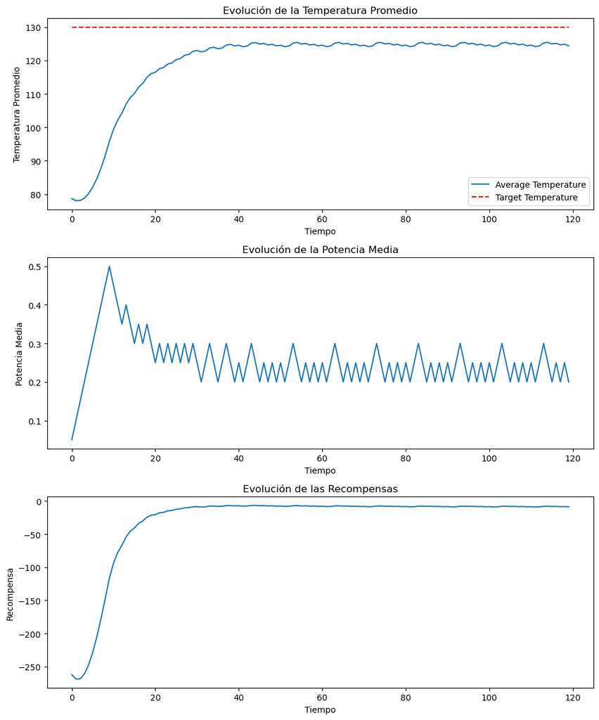

```
Temperatura final:
 [[104.72073  104.73268  104.768074 ... 105.20074  105.16592  105.154175]
 [104.73268  104.74463  104.78002  ... 105.21275  105.177925 105.16617 ]
 [104.76807  104.78003  104.81545  ... 105.248344 105.2135   105.20172 ]
 ...
 [105.20074  105.212746 105.24835  ... 105.68314  105.648125 105.6363  ]
 [105.165924 105.177925 105.2135   ... 105.64812  105.61314  105.60131 ]
 [105.15417  105.166176 105.20174  ... 105.6363   105.601326 105.58951 ]]
desviacion de la temperatura: 8.177155
```

```python
model = DQN.load("./best_model.zip")
obs, _ = env_eval.reset() #resetar entorno
info_history = []
while True:
    action, _ = model.predict(obs, deterministic=True)
    obs, reward, done, truncated, info = env_eval.step(action)
    info_history.append(info)


    if truncated or terminated:
        break

analyze_run(info_history)
final_temperature  = env_eval.temperature
print("Temperatura final:\n", final_temperature)
print("desviacion de la temperatura:", np.std(final_temperature))
```

Podemos observar como el agente entrenado con los mejores parametros se acerca a la temperatura objetivo pero no llega hasta el en el tiempo maximo

De la misma manera se observa que a partir del paso 20 la recompensa, las temperaturas y las potencias se van manteniendo debido a que aprende que llegado a un puto las mejores opciones se encuentran en subir o bajar la temperatura de una forma mas estables

Ejercicio 3.3 (2 puntos): Repite lo anterior pero ahora usando el espacio de acciones LampArrayPowerModifications_discrete. En vez de buscar los mejores hyperparametros, usa los mismos parametros que los anteriores a excepcion de parametros: learning_starts, num_episodes, target_update_interval, buffer_size y eval_frequency que simplemente los podeis multiplicar por un factor de 10. Un punto muy importante para este caso es modificar adecuadamente el espacio de observaciones. No busqueis valores de hiperparametros de la DQN pero si que jugad con los diferentes tipos de observaciones. Comenta como son los resultados encontrados asi como cuales son las diferencias tanto en resultados como en tiempo de entrenamiento respecto al caso anterior. Crees que es bueno usar un espacio de acciones discreto tan grande? Cual crees que es la solucion? Importante: No espereis encontrar resultados mucho mejores (o simplemente mejores) al apartado anterior

```python
To = 80 #Temperatura inicial

actions = LampArrayPowerModifications_discrete(N_LAMPS)
observation_space = TemperatureEnvObservation(temperature_mode= 'average',
                                              power_mode = 'average',
                                              normalize_temperature= True,
                                              return_power = True,
                                              buffer_size = 5)

reward_method = 'negative_error'
env = TemperatureEnv(N,
               K,
               SIG,
               To,
               CONV_COEF,
               actions,
               observation_space,
               reward_method = reward_method)

env_eval = TemperatureEnv(N,
               K,
               SIG,
               To,
               CONV_COEF,
               actions,
               observation_space,
               reward_method = reward_method,
               is_eval = True)

model = DQN("MlpPolicy",
            env,
            learning_starts = 10000,
            target_update_interval = 2500 ,
            learning_rate = 0.01,
            buffer_size = 5000,
            exploration_fraction = 0.2,
            tensorboard_log  = './logs')



callback = EvalCallback(eval_env = env_eval,
                        eval_freq = 100000,
                        best_model_save_path = './')

initial_eval = evaluate_policy(model,env_eval,n_eval_episodes = 5,deterministic = True)
model.learn(total_timesteps=100000,
            callback = callback,
            progress_bar = True)

final_eval = evaluate_policy(model,env_eval,n_eval_episodes = 5,deterministic = True)

print(f'Initial evaltuation {initial_eval}')
print(f'Final evaltuation {final_eval}')
```

```
Output()
```

```
Eval num_timesteps=100000, episode_reward=-3203.50 +/- 0.00
```

```
Episode length: 120.00 +/- 0.00
```

```
New best mean reward!
```

```
Initial evaltuation (-106582.70114135742, 0.0)
Final evaltuation (-3226.3459476605058, 0.0)
```

Se consiguen resultados un poco mejores que con el anterior apartado aunque el tiempo de ejecucion es mas elevado debido al numero de episodios

```python
model = DQN.load("./best_model.zip")

obs, _ = env_eval.reset()

info_history = [] #TODO:guardar en un array el historico
lamps = [] #TODO:guardar en un array el historico de potencias de las 9 lamparas. Usad env.lamp_power.
for i in range(500):
    action, _ = model.predict(obs, deterministic=True)

    if isinstance(action, np.ndarray):
        action = action.item()

    obs, reward, done, truncated, info = env_eval.step(action)
    info_history.append(info)
    lamps.append(env_eval.lamp_power.copy())

    print(f"paso {i+1}, recompensa: {reward}, temperatura media: {info['avg_temperature']}, temperatura objetivo: {info['target_temperature']}")

    if done or truncated:
        obs, _ = env_eval.reset()
```

```
paso 1, recompensa: -262.4084777832031, temperatura media: 78.67669677734375, temperatura objetivo: 130.0
paso 2, recompensa: -268.95599365234375, temperatura media: 78.0429916381836, temperatura objetivo: 130.0
paso 3, recompensa: -268.56097412109375, temperatura media: 78.08184051513672, temperatura objetivo: 130.0
paso 4, recompensa: -261.4145202636719, temperatura media: 78.77662658691406, temperatura objetivo: 130.0
paso 5, recompensa: -247.95834350585938, temperatura media: 80.11112213134766, temperatura objetivo: 130.0
paso 6, recompensa: -228.86399841308594, temperatura media: 82.06951904296875, temperatura objetivo: 130.0
paso 7, recompensa: -205.0133056640625, temperatura media: 84.63639831542969, temperatura objetivo: 130.0
paso 8, recompensa: -177.4799346923828, temperatura media: 87.79668426513672, temperatura objetivo: 130.0
paso 9, recompensa: -147.512451171875, temperatura media: 91.53572845458984, temperatura objetivo: 130.0
paso 10, recompensa: -121.95018768310547, temperatura media: 95.04432678222656, temperatura objetivo: 130.0
paso 11, recompensa: -100.25808715820312, temperatura media: 98.328125, temperatura objetivo: 130.0
paso 12, recompensa: -81.95069122314453, temperatura media: 101.39266967773438, temperatura objetivo: 130.0
paso 13, recompensa: -66.58887481689453, temperatura media: 104.24333953857422, temperatura objetivo: 130.0
paso 14, recompensa: -53.776981353759766, temperatura media: 106.88541412353516, temperatura objetivo: 130.0
paso 15, recompensa: -43.159889221191406, temperatura media: 109.32405090332031, temperatura objetivo: 130.0
paso 16, recompensa: -34.420310974121094, temperatura media: 111.56424713134766, temperatura objetivo: 130.0
paso 17, recompensa: -27.27627182006836, temperatura media: 113.61092376708984, temperatura objetivo: 130.0
paso 18, recompensa: -21.47869300842285, temperatura media: 115.4688491821289, temperatura objetivo: 130.0
paso 19, recompensa: -16.492156982421875, temperatura media: 117.28074645996094, temperatura objetivo: 130.0
paso 20, recompensa: -12.263830184936523, temperatura media: 119.04779815673828, temperatura objetivo: 130.0
paso 21, recompensa: -8.743826866149902, temperatura media: 120.77110290527344, temperatura objetivo: 130.0
paso 22, recompensa: -5.885029315948486, temperatura media: 122.45172119140625, temperatura objetivo: 130.0
paso 23, recompensa: -3.64294695854187, temperatura media: 124.09075927734375, temperatura objetivo: 130.0
paso 24, recompensa: -1.975571870803833, temperatura media: 125.68922424316406, temperatura objetivo: 130.0
paso 25, recompensa: -0.8432478308677673, temperatura media: 127.24811553955078, temperatura objetivo: 130.0
paso 26, recompensa: -0.208549365401268, temperatura media: 128.76840209960938, temperatura objetivo: 130.0
paso 27, recompensa: -0.03616296499967575, temperatura media: 130.25106811523438, temperatura objetivo: 130.0
paso 28, recompensa: -0.29277706146240234, temperatura media: 131.69705200195312, temperatura objetivo: 130.0
paso 29, recompensa: -0.9469767808914185, temperatura media: 133.1072235107422, temperatura objetivo: 130.0
paso 30, recompensa: -1.9691437482833862, temperatura media: 134.4824981689453, temperatura objetivo: 130.0
paso 31, recompensa: -3.331362009048462, temperatura media: 135.82373046875, temperatura objetivo: 130.0
paso 32, recompensa: -5.007327556610107, temperatura media: 137.13174438476562, temperatura objetivo: 130.0
paso 33, recompensa: -6.972264766693115, temperatura media: 138.40740966796875, temperatura objetivo: 130.0
paso 34, recompensa: -8.222557067871094, temperatura media: 139.13278198242188, temperatura objetivo: 130.0
paso 35, recompensa: -8.54423999786377, temperatura media: 139.32144165039062, temperatura objetivo: 130.0
paso 36, recompensa: -7.90067720413208, temperatura media: 138.98667907714844, temperatura objetivo: 130.0
paso 37, recompensa: -7.295668601989746, temperatura media: 138.66012573242188, temperatura objetivo: 130.0
paso 38, recompensa: -6.727145195007324, temperatura media: 138.34164428710938, temperatura objetivo: 130.0
paso 39, recompensa: -6.193136692047119, temperatura media: 138.031005859375, temperatura objetivo: 130.0
paso 40, recompensa: -5.691776275634766, temperatura media: 137.72804260253906, temperatura objetivo: 130.0
```

[output cut: 445 more lines]

```
paso 486, recompensa: -228.86399841308594, temperatura media: 82.06951904296875, temperatura objetivo: 130.0
paso 487, recompensa: -205.0133056640625, temperatura media: 84.63639831542969, temperatura objetivo: 130.0
paso 488, recompensa: -177.4799346923828, temperatura media: 87.79668426513672, temperatura objetivo: 130.0
paso 489, recompensa: -147.512451171875, temperatura media: 91.53572845458984, temperatura objetivo: 130.0
paso 490, recompensa: -121.95018768310547, temperatura media: 95.04432678222656, temperatura objetivo: 130.0
paso 491, recompensa: -100.25808715820312, temperatura media: 98.328125, temperatura objetivo: 130.0
paso 492, recompensa: -81.95069122314453, temperatura media: 101.39266967773438, temperatura objetivo: 130.0
paso 493, recompensa: -66.58887481689453, temperatura media: 104.24333953857422, temperatura objetivo: 130.0
paso 494, recompensa: -53.776981353759766, temperatura media: 106.88541412353516, temperatura objetivo: 130.0
paso 495, recompensa: -43.159889221191406, temperatura media: 109.32405090332031, temperatura objetivo: 130.0
paso 496, recompensa: -34.420310974121094, temperatura media: 111.56424713134766, temperatura objetivo: 130.0
paso 497, recompensa: -27.27627182006836, temperatura media: 113.61092376708984, temperatura objetivo: 130.0
paso 498, recompensa: -21.47869300842285, temperatura media: 115.4688491821289, temperatura objetivo: 130.0
paso 499, recompensa: -16.492156982421875, temperatura media: 117.28074645996094, temperatura objetivo: 130.0
paso 500, recompensa: -12.263830184936523, temperatura media: 119.04779815673828, temperatura objetivo: 130.0
```

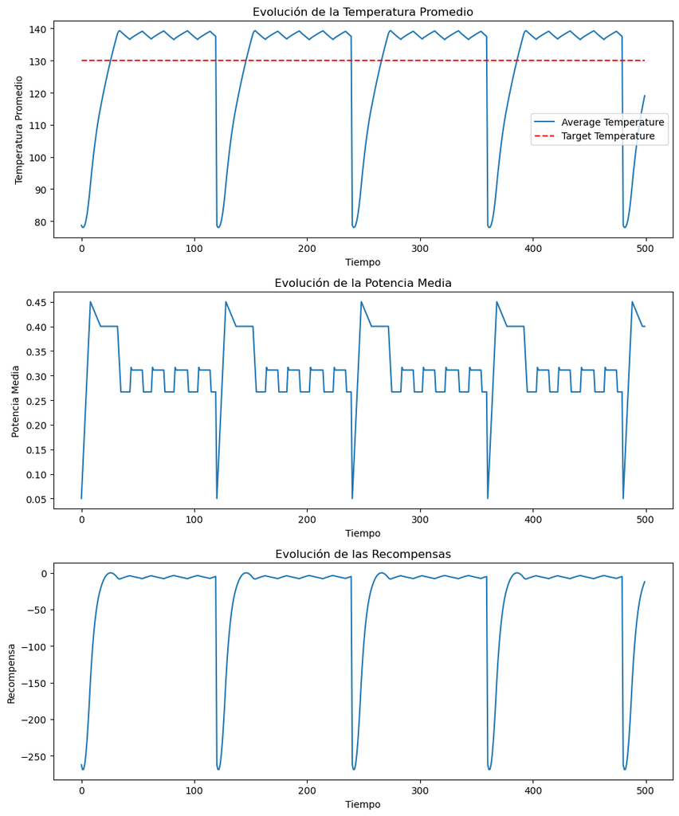

```
temperatura objetivo:
 [[107.702866 107.71532  107.751945 ... 108.01473  107.97884  107.96666 ]
 [107.71532  107.72776  107.7644   ... 108.02721  107.99132  107.979126]
 [107.751945 107.76439  107.80103  ... 108.0639   108.02801  108.01581 ]
 ...
 [108.014725 108.02719  108.06387  ... 108.32746  108.29153  108.27931 ]
 [107.978836 107.99131  108.02801  ... 108.29152  108.25558  108.24338 ]
 [107.966644 107.97912  108.01581  ... 108.279305 108.24336  108.23116 ]]
temperatura objetivo: 3.5619617
```

```python
analyze_run(info_history)

final_temperature  = env_eval.temperature
print("temperatura objetivo:\n", final_temperature)
print("temperatura objetivo:", np.std(final_temperature))
```

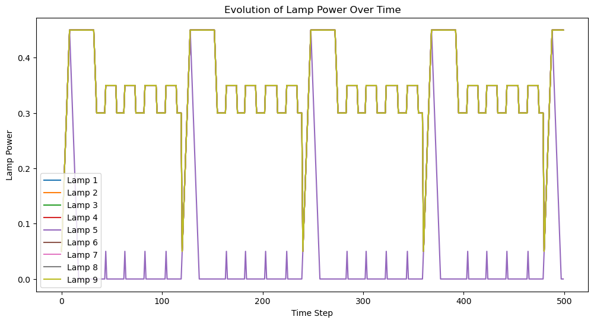

```python
def plot_lamps(lamps):
    plt.figure(figsize=(12, 6))
    for i in range(len(lamps[0])):
        lamp_powers = [lamp[i] for lamp in lamps]
        plt.plot(lamp_powers, label=f'Lamp {i+1}')
    plt.xlabel('Time Step')
    plt.ylabel('Lamp Power')
    plt.title('Evolution of Lamp Power Over Time')
    plt.legend()
    plt.show()

plot_lamps(lamps)
```

Podemos observar que al utilizar el espacio de acciones discreto se encuentran picos y bajadas en el caso. Esta vez si se llega a la temperatura objetivo.

En el caso de ltiempo de ejecucion se tarda mas debido a que se tienen que cargar mas numero de pasos para completar

Ejercicio 3.4 (2 puntos) Entrenamiento A2C. Usando ahora el espacio de acciones LampArrayPowerModifications_continious. Debido a que el espacio de acciones es continuo, no podemos usar el modelo DQN. Usaremos, por lo tanto, el modelo A2C. Entrena el modelo probando modificando los hiperparametros: * n_steps = [3,5,10] con ent_coef = 0.1 * ent_coef = [0,0.1,1] con n_steps = 5 Usad 30 mil iteraciones en todos los casos. Comenta el efecto de ambos parametros en el resultado final y compara los resultados del agente en este caso vs lo visto en los dos casos anteriores

```python
#No modificar nada de aqui
actions = LampArrayPowerModifications_continious(N_LAMPS)


observation_space = TemperatureEnvObservation(temperature_mode='lamp',
                          power_mode = 'lamp',
                          normalize_temperature=False,
                          return_power = True,
                          buffer_size = 2)

reward_method = 'negative_error'
env = TemperatureEnv(N,
               K,
               SIG,
               To,
               CONV_COEF,
               actions,
               observation_space,
               reward_method = reward_method)

env_eval = env = TemperatureEnv(N,
               K,
               SIG,
               To,
               CONV_COEF,
               actions,
               observation_space,
               reward_method = reward_method,
               is_eval = True)
```

```python
from stable_baselines3 import A2C
import torch as th

policy_kwargs = dict(activation_fn=th.nn.ReLU,
                     net_arch=dict(pi=[128, 64, 32, 9], vf=[128, 64, 32, 9]))

n_steps_values = [3, 5, 10]
ent_coef_values = [0, 0.1, 1]

for n_steps in n_steps_values:
    for ent_coef in ent_coef_values:
        print(f"modelo con n_steps={n_steps}, ent_coef={ent_coef}")

        model = A2C("MlpPolicy",
                    env,
                    policy_kwargs=policy_kwargs,
                    learning_rate=0.01,
                    n_steps=n_steps,
                    ent_coef=ent_coef
                    )

        callback = EvalCallback(eval_env=env_eval, eval_freq=5000,
                                best_model_save_path=f'./best_model_n_steps_{n_steps}_ent_coef_{ent_coef}')
        initial_eval = evaluate_policy(model, env, n_eval_episodes=5)
        model.learn(total_timesteps=30000,
                    callback=callback,
                    progress_bar=True)
        final_eval = evaluate_policy(model, env, n_eval_episodes=5)
        print("Evaluación final:", final_eval)
        model.save(f"./a2c_model_n_steps_{n_steps}_ent_coef_{ent_coef}")
```

```
modelo con n_steps=3, ent_coef=0
```

```
Output()
```

```
Eval num_timesteps=5000, episode_reward=-78958.97 +/- 0.00
```

```
Episode length: 120.00 +/- 0.00
```

```
New best mean reward!
```

```
Eval num_timesteps=10000, episode_reward=-77630.79 +/- 0.00
```

```
Episode length: 120.00 +/- 0.00
```

```
New best mean reward!
```

```
Eval num_timesteps=15000, episode_reward=-56170.55 +/- 0.00
```

```
Episode length: 120.00 +/- 0.00
```

```
New best mean reward!
```

```
Eval num_timesteps=20000, episode_reward=-56458.08 +/- 0.00
```

```
Episode length: 120.00 +/- 0.00
```

```
Eval num_timesteps=25000, episode_reward=-62280.72 +/- 0.00
```

```
Episode length: 120.00 +/- 0.00
```

```
Eval num_timesteps=30000, episode_reward=-39062.85 +/- 0.00
```

```
Episode length: 120.00 +/- 0.00
```

```
New best mean reward!
```

```
Evaluación final: (-38546.264083862305, 0.0)
modelo con n_steps=3, ent_coef=0.1
```

```
Output()
```

```
Eval num_timesteps=5000, episode_reward=-84674.27 +/- 0.00
```

```
Episode length: 120.00 +/- 0.00
```

```
New best mean reward!
```

```
Eval num_timesteps=10000, episode_reward=-42747.32 +/- 0.00
```

```
Episode length: 120.00 +/- 0.00
```

```
New best mean reward!
```

```
Eval num_timesteps=15000, episode_reward=-74907.73 +/- 0.00
```

```
Episode length: 120.00 +/- 0.00
```

```
Eval num_timesteps=20000, episode_reward=-204730.95 +/- 0.00
```

```
Episode length: 120.00 +/- 0.00
```

```
Eval num_timesteps=25000, episode_reward=-379146.85 +/- 0.00
```

```
Episode length: 120.00 +/- 0.00
```

```
Eval num_timesteps=30000, episode_reward=-100801.09 +/- 0.00
```

```
Episode length: 120.00 +/- 0.00
```

```
Evaluación final: (-101561.5251159668, 0.0)
modelo con n_steps=3, ent_coef=1
```

```
Output()
```

```
Eval num_timesteps=5000, episode_reward=-185107.18 +/- 0.00
```

```
Episode length: 120.00 +/- 0.00
```

```
New best mean reward!
```

```
Eval num_timesteps=10000, episode_reward=-129451.92 +/- 0.00
```

```
Episode length: 120.00 +/- 0.00
```

```
New best mean reward!
```

```
Eval num_timesteps=15000, episode_reward=-65160.47 +/- 0.00
```

```
Episode length: 120.00 +/- 0.00
```

```
New best mean reward!
```

```
Eval num_timesteps=20000, episode_reward=-70358.47 +/- 0.00
```

```
Episode length: 120.00 +/- 0.00
```

```
Eval num_timesteps=25000, episode_reward=-76067.82 +/- 0.00
```

```
Episode length: 120.00 +/- 0.00
```

```
Eval num_timesteps=30000, episode_reward=-77463.06 +/- 0.00
```

```
Episode length: 120.00 +/- 0.00
```

```
Evaluación final: (-77670.35684204102, 0.0)
modelo con n_steps=5, ent_coef=0
```

```
Output()
```

```
Eval num_timesteps=5000, episode_reward=-137193.86 +/- 0.00
```

```
Episode length: 120.00 +/- 0.00
```

```
New best mean reward!
```

```
Eval num_timesteps=10000, episode_reward=-137193.86 +/- 0.00
```

```
Episode length: 120.00 +/- 0.00
```

```
Eval num_timesteps=15000, episode_reward=-91162.79 +/- 0.00
```

```
Episode length: 120.00 +/- 0.00
```

```
New best mean reward!
```

```
Eval num_timesteps=20000, episode_reward=-92945.17 +/- 0.00
```

```
Episode length: 120.00 +/- 0.00
```

[output not shown]

```
Eval num_timesteps=30000, episode_reward=-57820.52 +/- 0.00
```

```
Episode length: 120.00 +/- 0.00
```

```
Evaluación final: (-59078.546875, 0.0)
modelo con n_steps=5, ent_coef=0.1
```

```
Output()
```

```
Eval num_timesteps=5000, episode_reward=-90103.38 +/- 0.00
```

```
Episode length: 120.00 +/- 0.00
```

```
New best mean reward!
```

```
Eval num_timesteps=10000, episode_reward=-37316.76 +/- 0.00
```

```
Episode length: 120.00 +/- 0.00
```

```
New best mean reward!
```

```
Eval num_timesteps=15000, episode_reward=-95362.53 +/- 0.00
```

```
Episode length: 120.00 +/- 0.00
```

```
Eval num_timesteps=20000, episode_reward=-338084.53 +/- 0.00
```

```
Episode length: 120.00 +/- 0.00
```

```
Eval num_timesteps=25000, episode_reward=-60408.79 +/- 0.00
```

```
Episode length: 120.00 +/- 0.00
```

```
Eval num_timesteps=30000, episode_reward=-130786.29 +/- 0.00
```

```
Episode length: 120.00 +/- 0.00
```

```
Evaluación final: (-130956.95016479492, 0.0)
modelo con n_steps=5, ent_coef=1
```

```
Output()
```

```
Eval num_timesteps=5000, episode_reward=-137193.86 +/- 0.00
```

```
Episode length: 120.00 +/- 0.00
```

```
New best mean reward!
```

```
Eval num_timesteps=10000, episode_reward=-137193.86 +/- 0.00
```

```
Episode length: 120.00 +/- 0.00
```

```
Eval num_timesteps=15000, episode_reward=-137193.86 +/- 0.00
```

```
Episode length: 120.00 +/- 0.00
```

```
Eval num_timesteps=20000, episode_reward=-137193.86 +/- 0.00
```

```
Episode length: 120.00 +/- 0.00
```

```
Eval num_timesteps=25000, episode_reward=-137193.86 +/- 0.00
```

```
Episode length: 120.00 +/- 0.00
```

```
Eval num_timesteps=30000, episode_reward=-137193.86 +/- 0.00
```

```
Episode length: 120.00 +/- 0.00
```

```
Evaluación final: (-137193.86471557617, 0.0)
modelo con n_steps=10, ent_coef=0
```

```
Output()
```

```
Eval num_timesteps=5000, episode_reward=-137193.86 +/- 0.00
```

```
Episode length: 120.00 +/- 0.00
```

```
New best mean reward!
```

```
Eval num_timesteps=10000, episode_reward=-42729.55 +/- 0.00
```

```
Episode length: 120.00 +/- 0.00
```

```
New best mean reward!
```

```
Eval num_timesteps=15000, episode_reward=-137193.86 +/- 0.00
```

```
Episode length: 120.00 +/- 0.00
```

```
Eval num_timesteps=20000, episode_reward=-60289.77 +/- 0.00
```

```
Episode length: 120.00 +/- 0.00
```

```
Eval num_timesteps=25000, episode_reward=-26710.04 +/- 0.00
```

```
Episode length: 120.00 +/- 0.00
```

```
New best mean reward!
```

```
Eval num_timesteps=30000, episode_reward=-37121.71 +/- 0.00
```

```
Episode length: 120.00 +/- 0.00
```

```
Evaluación final: (-37064.14483642578, 0.0)
modelo con n_steps=10, ent_coef=0.1
```

```
Output()
```

```
Eval num_timesteps=5000, episode_reward=-234156.20 +/- 0.00
```

```
Episode length: 120.00 +/- 0.00
```

```
New best mean reward!
```

```
Eval num_timesteps=10000, episode_reward=-163498.71 +/- 0.00
```

```
Episode length: 120.00 +/- 0.00
```

```
New best mean reward!
```

```
Eval num_timesteps=15000, episode_reward=-42627.96 +/- 0.00
```

```
Episode length: 120.00 +/- 0.00
```

```
New best mean reward!
```

```
Eval num_timesteps=20000, episode_reward=-215037.50 +/- 0.00
```

```
Episode length: 120.00 +/- 0.00
```

```
Eval num_timesteps=25000, episode_reward=-79511.70 +/- 0.00
```

```
Episode length: 120.00 +/- 0.00
```

```
Eval num_timesteps=30000, episode_reward=-79817.37 +/- 0.00
```

```
Episode length: 120.00 +/- 0.00
```

```
Evaluación final: (-79814.40939331055, 0.0)
modelo con n_steps=10, ent_coef=1
```

```
Output()
```

```
Eval num_timesteps=5000, episode_reward=-113921.11 +/- 0.00
```

```
Episode length: 120.00 +/- 0.00
```

```
New best mean reward!
```

```
Eval num_timesteps=10000, episode_reward=-94487.52 +/- 0.00
```

```
Episode length: 120.00 +/- 0.00
```

```
New best mean reward!
```

```
Eval num_timesteps=15000, episode_reward=-303641.52 +/- 0.00
```

```
Episode length: 120.00 +/- 0.00
```

```
Eval num_timesteps=20000, episode_reward=-184023.40 +/- 0.00
```

```
Episode length: 120.00 +/- 0.00
```

```
Eval num_timesteps=25000, episode_reward=-184023.40 +/- 0.00
```

```
Episode length: 120.00 +/- 0.00
```

```
Eval num_timesteps=30000, episode_reward=-232920.61 +/- 0.00
```

```
Episode length: 120.00 +/- 0.00
```

```
Evaluación final: (-232920.60740852356, 0.0)
```

Al realizar las comprobaciones con mas parametros de los que nos ha indicado el ejercicio se puede ver como la mejor evaluacion fuera de los parametros son de n steps 10 t ent_cof 0